# Coursework Report

*N* removed NAs: 6

*N* removed <18: 20

**Correct typo age:** 21

*N* total clean: 142

| Group | *N* | *M*<sub>age</sub> | % green |
| --- | --- | --- | --- |
| Control | 71 | 20.99 | 37.09 |
| Experim | 71 | 21.17 | 51.64 |

| Gender | *N* | *M*<sub>age</sub> | % green |
| --- | --- | --- | --- |
| Female | 72 | 21.18 | 44.91 |
| Male | 44 | 21.14 | 42.42 |
| Other | 26 | 20.69 | 46.15 |

**Main analysis results**

**car:**  
χ<sup>2</sup>(1) = 0.71, *p* = .401

**cleaner:**  
χ<sup>2</sup>(1) = 3.53, *p* = .060

**dishwasher:**  
χ<sup>2</sup>(1) = 4.11, *p* = .043

[interactive chart not shown]

[figure not shown]

[interactive chart not shown]

# Coursework Report

Analysing Data, Spring 2020

# Methods

## Participants

Table One

| . | Freq |
| --- | --- |
| female | 252 |
| male | 165 |
| other | 87 |

Table Two

| . | Freq |
| --- | --- |
| female | 216 |
| male | 132 |
| other | 77 |

Table Three

| Mean.age | SD.age | Min.age | Max.age |
| --- | --- | --- | --- |
| 21.08 | 1.83 | 18 | 26 |

## Design

The conceptual hypothesis states, ‘People who have higher-status motives are more likely to choose a green product over a luxury product then those who are shown a neutral status motive’.

The design of the study was a two between-subjects study. Being independent groups, it meant that each participant was either put into the control or experimental group and then given one of the products and did not do any other versions of the study. The two independent variables for this study were the motive primes and the type of product. The motive primes were either the control group who had a status-neutral short story to read or the experimental group who had high-status short story to read prior to choosing the product. The type of product would be between a car, a household cleaner and a dishwasher, all of which the participants were told to imagine they were going out to buy one of them. The dependent variable was the choice of product. This was measured by asking the participants a two-option question - ‘If you were out shopping for a new car/dishwasher/household cleaner, which of these two products would you buy?’. The choice would then be between the green option or the luxury option.

In order to make sure the study was measuring between the types of product - green or luxury - the two versions of the products were the same price, for example, both dishwashers were $1100. All products also had similar descriptions and were made by the same manufacturing brand.

Therefore, the operational hypothesis for this study states ‘People are more likely to buy a pro-environmental car, cleaner or dishwasher then a luxury car, cleaner or dishwasher when reading a short story to produce high-status motives rather than a short-story that produces status-neutral motives, prior to choosing the product’ and in order to test this hypothesis multiple chi-squared statistical tests will be conducted.

# Results

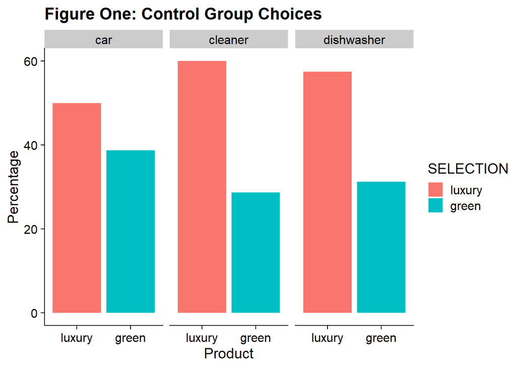

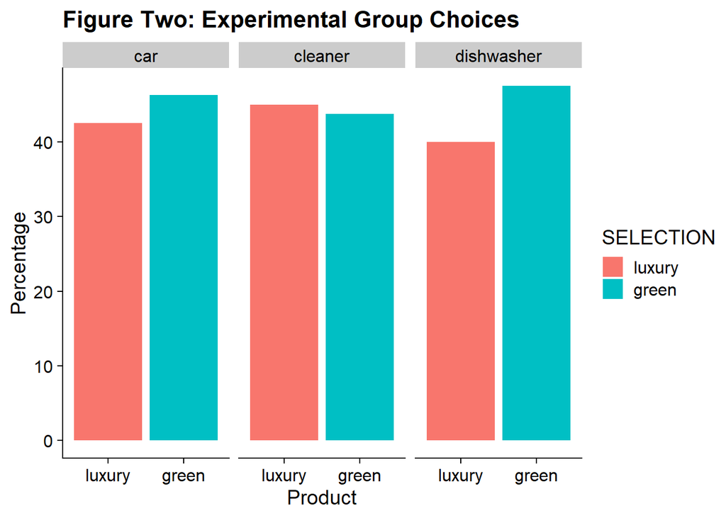

In the controlled condition, as shown in Figure One, participants were more likely to choose the luxury product over the green product. In the findings, all three of the products luxury versions were chosen by half or over half the participants, with the green products being chosen by 38.75% for the car, 28.75% for the cleaner and 31.25% for the dishwasher. Then in comparison to Figure Two, it can be seen that the green product choice increased for all three products, with the car increasing to 46.25%, the cleaner to 43.75% and the dishwasher to 47.50%.

The study was looking at whether there was a relationship between high-status motives and product choice. Therefore, multiple chi-squared analysis tests were conducted to investigate whether the groups (high-status motives and status-neutral motives) were associated with the selection of the product (Luxury vs Control) for all three products.

# Discussion

This study looked into whether high-status motives effected the choice of product between a luxury one and a pro-environmental one. It was hypothesised that those who had high-status motives were more likely to choose the pro-environmental product over the luxury product in comparison to the controlled condition. Overall, the results showed a large increase between the percentage of participants choosing the green product in the high-status motive condition in comparison to those in the neutral-status motive condition and consequently this suggests that high-status motives do increase the likelihood of someone choosing a green product over the luxury product.

In comparison to the original study, the results matched for both of the hypotheses. The first was that the controlled status group would show a higher preference for the luxury products. Griskevicius, Tybur and Van den Bergh (2010) found 62.8% chose the non-green car over the luxury car, 74.3% choosing the non-green cleaner and 65.5% for the non-green dishwasher. Similarly in this study in the controlled condition, 50% chose the luxury car, 60% the luxury cleaner and 57.5% for the luxury dishwasher.

The second hypothesis was what this study tested which was, ‘participants who had high-status motives would be more likely to pick the green product then those in the controlled condition who had status-neutral motives’ and Griskevicius et al (2010) results showed 54.5% chose the car in the high-status motive condition, whereas only 37.2% chose it in the controlled condition and further results in the high-status condition were 41.8% chose the green cleaner and 49.1% the green dishwasher; both of which had lower percentages of being picked in the controlled condition. In this study, the results followed the same trend with 46.25% choosing the green car, with only 38.75% choosing it in the controlled condition, 43.75% choosing the green cleaner and 47.5% choosing the green dishwasher and both again having a lower percentage of being picked in the status-neutral condition.

These results can also be reflected in a survey, as it was found that factors like fuel economy and emissions levels were very low on a list when asking people the reasons to why they were buying an hybrid car and at the top of the list was people wanting to make a statement about themselves (Maynard, 2007, cited in Griskevicius et al., 2010, p. 399). This suggests that it is active status motives that cause people to buy more green products, as people will self-sacrifice the luxury of a comfortable car or high-end cleaner for a green, less comfortable car or product in order to show other people that they care about the environment and society (Griskevicius et al., 2010).

However, a limitation of this study was that the participants did not actually buy the product and had to imagine buying them. This meant that the conclusions drawn were only as good as the participants ability to imagine what they were buying and then remembering why they chose the particular product in the recall task, which would have been affected by memory decay. In turn, this causes the real-life application for the study to be a lot weaker and it cannot be said whether the participants would make the same decision if they were asked to actually go and buy the product in a store. Furthermore, the study did not take into account personal characteristics, such as gender or financial stability. A study by Drozdenko, Jensen and Coelho (2011) found that people were more likely to buy a green product, as long as it had a saving in a different way, for example; a car if it was green and quite expensive, would only be bought if it would save costs on petrol. This means that it cannot be said that if the luxury product was cheaper than a green product people would still decide to choose green when given high-status motives prior to the decision. Also, there is evidence that suggests that women are naturally more altruistic then men and are more likely to self-sacrifice then men (Rand, Brescoll, Everett, Capraro & Barcelo, 2016). Therefore, in the study if those who did buy the green products were majority women, the results cannot be generalised across all genders and it cannot be concluded that the high-status motives have an effect on men when buying a green product.

Therefore, future studies will need to explore the demographical and look deeper into the psychological reasons for why someone would choose a green product over a luxury product. As Rand et al. (2016) discussed how women were naturally more self-sacrificing then men, it would be interesting to look into whether they are more affected by high-status motives in general and because of this buy more pro-environmental products than their male counterpart. This would be valuable for areas such as company marketing, as it will help them to identify their target market and what sort of marketing – whether that would be high-status motives in their campaign or something else – to use to attract the most sales.

# References

Drozdenko, R., Jensen, M. & Coelho, D. (2011). Pricing of Green Products: Premiums Paid, Consumer Characteristics and Incentives. *International Journal of Business, Marketing and Decision Sciences, 4*(1), 106-116.

Griskevicius, V., Tybur, J. & Van den Bergh, B. (2010). Going Green to be Seen: Status, Reputation and Conspicuous Conservation. *Journal of Personality and Social Psychology, 98*(3), 392-404. Doi: 10.1037/a0017346

Maynard, M. (2007, July 4) Say ‘Hybrid’ and many people will hear ‘Prius’. *New York Times*. Retrieved from https://www.nytimes.com/2007/07/04/business/04hybrid.html

Rand, D., Brescoll, V., Everett, J., Capraro, V. & Barcelo, H. (2016). Social Heuristics and Social Roles: Intuition Favours Altruism for Women but Not for Men. *Journal of Experimental Psychology: General, 145*(4), 389-396. Doi: https://doi.org/10.1037/xge0000154